# MDSS Introduction to R Workshop Part 3

### Different Geoms

There are many types of plots that can be made with ggplot, far too many to be discussed here. In this session we explictly talk only about a small subset of the plots.

To read all the geoms that ggplot implements read here:

https://ggplot2.tidyverse.org/reference/

There are also many packages that extend the capabilities of ggplot for visuals that are specific to other fields.

### Line plots

Line plots work well with timeseries data. In this example we investigate whether the price of properties have increased over time.

```r
if(!require(lubridate)){
  install.packages("lubridate")
  library(lubridate)
}
```

Here we create a data frame that contains the average sale price for each month.

```r
time_trends <- housing_data %>%
  group_by(Month = floor_date(as.POSIXct(Date,format="%d/%m/%Y"),"month")) %>%
  summarise(Price = mean(Price))
```

```r
View(time_trends)
```

Here we use geom line to create a lineplot. In the `aes` function we specify exactly what we want from the data.

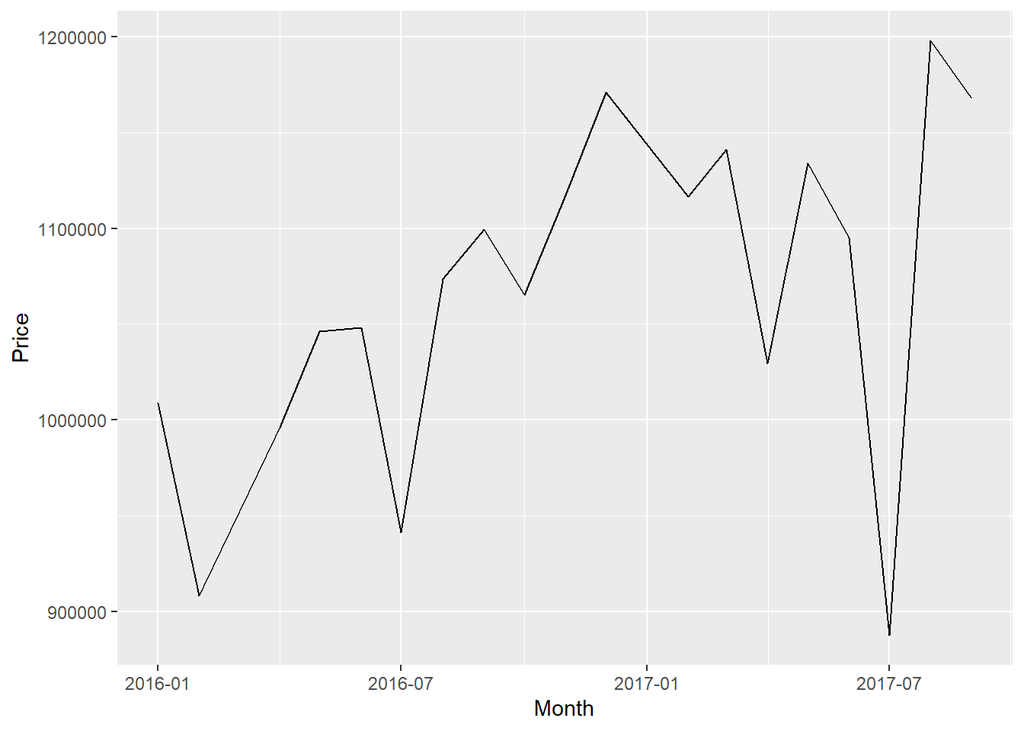

```r
ggplot(time_trends, aes(x=Month, y=Price)) +
    geom_line()
```

We have a generally increasing trend with July 2017 being an anomolously low month.

**Question**

Using the following code, create the same line chart, but with a single line for each region.

*hint* use the `col =` in the aes function

```r
time_trends2 <- housing_data %>%
  group_by(Month = floor_date(as.POSIXct(Date,format="%d/%m/%Y"),"month"), Regionname) %>%
  summarise(Price = mean(Price))
View(time_trends2)
```

### Boxplots

In our data we have a column called “Type” this is u for unit, h for house and t for townhouse. In the following example we expand this using a `case_when` function and then use ggplot to create a boxplot.

Note the `aes` can go in either the main `ggplot` function or in the `geom_*` function.

We can even compose a graph with different `aes` on each geom.

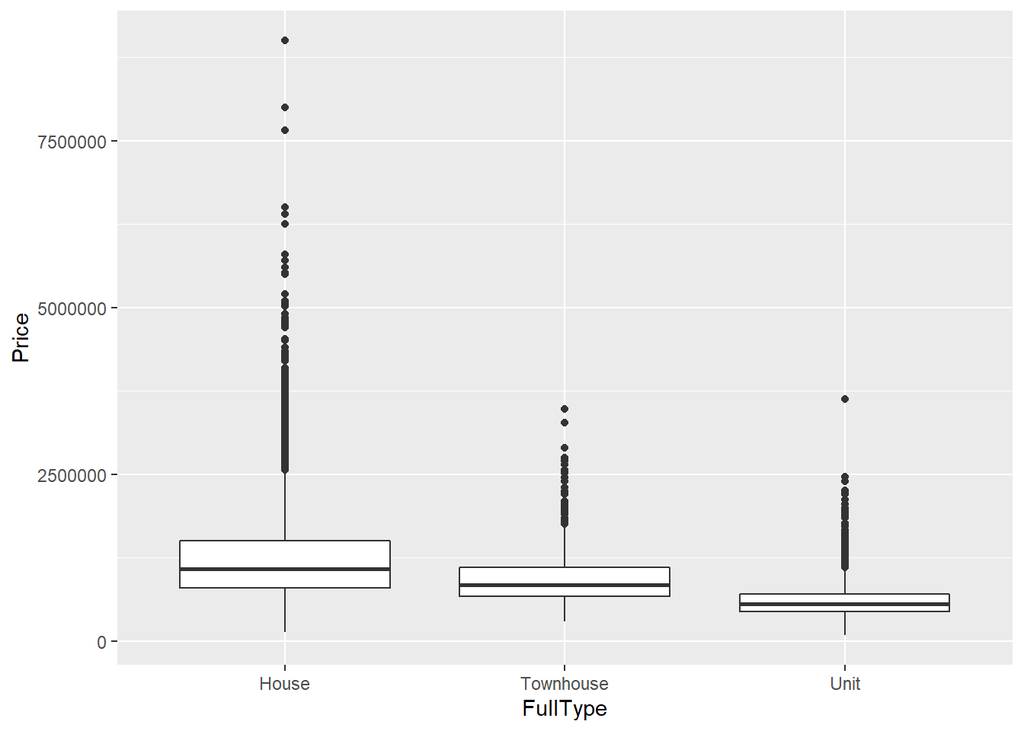

```r
housing_data <- housing_data %>% mutate(FullType = case_when(Type == 'u'~ "Unit",
                                                             Type == 't'~ "Townhouse",
                                                             Type == 'h'~ "House"))

p<- ggplot(housing_data)+geom_boxplot(aes(x =FullType ,y= Price))
p
```

**Question**

Have a look at the full list of geoms that we can create in ggplot.

https://ggplot2.tidyverse.org/reference/

## Faceting

Faceting produces small multiples, single charts for each segment. Here we use `facet_wrap()`, there are also other `facet_*` functions that let us change the layout of the facets.

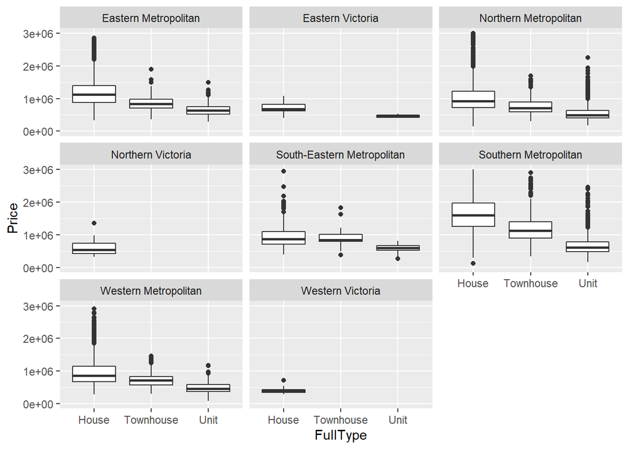

```r
p<- ggplot(housing_data)+geom_boxplot(aes(x =FullType ,y= Price))+facet_wrap(~Regionname)+ylim(0,3e6)
p
```

**Question**

Use Facet wrap to produce small multiples for any graph from before.

## Themes

Ggplot contains a number of different themes to customise the appearance of your plots. You can use this to produce custom graphics.

Here is an example.

```r
ForGraph <- housing_data %>%
  group_by(Suburb) %>%
  summarise(AvePrice = mean(Price),Count = n()) %>%
  arrange(desc(AvePrice)) %>%
  filter(Count > 10) %>%
  head(10)
```

```r
HousePricePlot <- ggplot(ForGraph,aes(x=reorder(Suburb,desc(AvePrice)),y=AvePrice)) + geom_bar(stat="identity",fill="steelblue") +
    theme_classic()+
    theme(axis.text.x = element_text(angle = 60, hjust=1),
        axis.title.x=element_blank(),
        axis.ticks.x =element_blank(),
        plot.title = element_text(hjust = 0.5,vjust = 1)) +
  ylab("Average House Sale Price")+
  scale_y_continuous(expand = c(0,0),labels=scales::dollar_format())+
  ggtitle("Most expenisve suburbs in Melbourne")
```

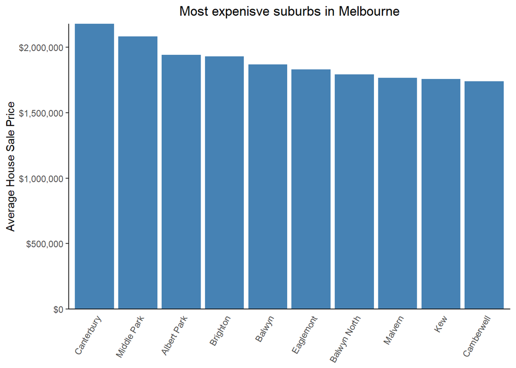

```r
HousePricePlot
```

**Question**

Ggplot contains many inbuilt themes. Save any of the previous graphs in a variable using `<-` and then add a theme to it.

Some inbuilt themes include `theme_minimal()`, `theme_linedraw()`, `theme_dark()`.

The `theme()` function allows us to make changes to very specific parts of a plot.

## Saving a plot

Use the `ggsave` function to save a high quality image onto your hard disk for later. Here we are saving the last plot as housing_type.png

```r
ggsave("housing_type.png", p)
```

**Question**

Save any of the previously produced charts.

## Additional miscellaneous Graphics

```r
download.file("https://data.gov.au/data/dataset/af33dd8c-0534-4e18-9245-fc64440f742e/resource/3b946968-319e-4125-8971-2a33d5bf000c/download/vic_loc_polygon_shp.zip" , destfile="DATA/suburb_shape_file.zip")
unzip("DATA/suburb_shape_file.zip",exdir = "/DATA/suburb_shape_file")
```

```r
library(sf)
sf_df <- st_read("/DATA/suburb_shape_file/VIC_LOC_POLYGON_shp/vic_localities.shp")
```

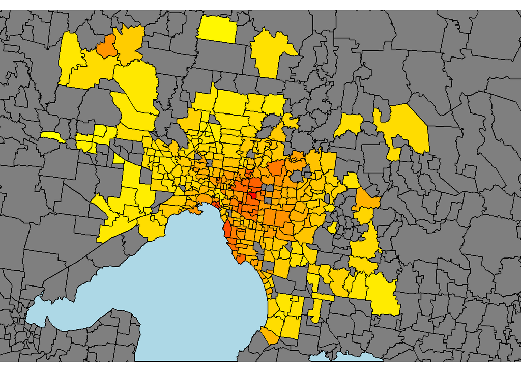

```r
average_price <- housing_data %>% filter(Longtitude<146,Longtitude>144, ) %>% group_by(Suburb) %>% summarise(mean_price =mean(Price))

data_final<- left_join(sf_df,average_price, by =c( "LOC_NAME" ="Suburb"))

plt <- ggplot()+
  geom_sf(data = data_final,aes(geometry=geometry,fill=mean_price),col="black")+
  xlim(c(144.35,145.85))+
  ylim(c(-38.2,-37.4))+
  theme_void()+
  theme(panel.background = element_rect("lightblue"),
        legend.position = "none")+
  scale_fill_gradient(
    low = "yellow",
    high = "red",
    space = "Lab",
    na.value = "grey50",
    guide = "colourbar",
    aesthetics = "fill"
  )
plt
```

```r
#ggsave("map.pdf",plt)
```

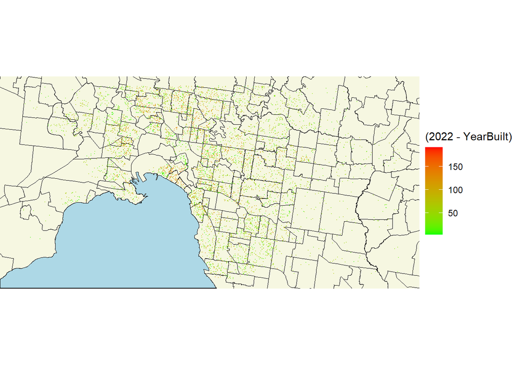

```r
plt2 <-  ggplot()+
  geom_sf(data = data_final,aes(geometry=geometry),fill = "#f6f7e1",col="black",size = 0.02)+
  xlim(c(144.75,145.25))+
  ylim(c(-37.95,-37.75))+
  geom_point(data = housing_data %>% filter(YearBuilt>1800),mapping = aes(x=Longtitude,y=Lattitude,col = (2022- YearBuilt)),size = 0.003,alpha = 0.5)+
  theme_void()+
  theme(panel.background = element_rect("lightblue"))+
  scale_colour_gradient(
    low = "green",
    high = "red",
    space = "Lab",
    na.value = "grey50",
    guide = "colourbar",
    aesthetics = "col"
  )
plt2
```

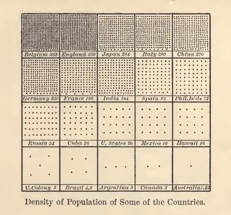

```r
#ggsave("map2.pdf",plt2)
```

```r
library(tidyverse)
library(janitor)
library(httr)
library(XML)
#create the data


Countries <- c("Belgium","United Kingdom","Japan","Italy","China","Germany","France","India","Spain","Philippines","Russia","Cuba","United States","Mexico",'Nigeria',"South Africa","Brazil","Argentina","Canada","Australia")

url <- "https://en.wikipedia.org/wiki/List_of_countries_and_dependencies_by_population_density"

r <- GET(url)

doc <- readHTMLTable(
  doc=content(r, "text"))

density_table <- doc[[1]]

density_table <- density_table %>% row_to_names(row_number = 1)
```

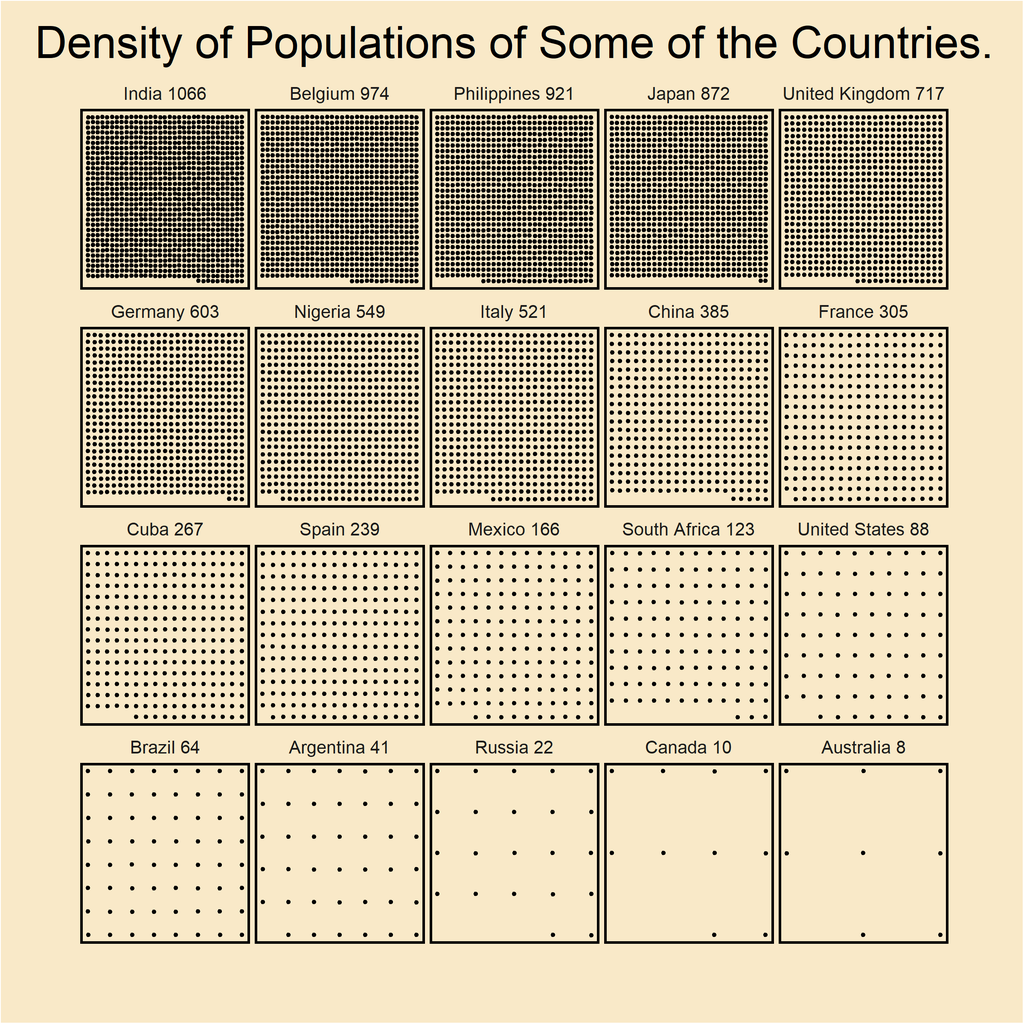

```r
density_table <- density_table[2:nrow(density_table),]

names(density_table) <- c("country","population","area_mi","area_km","pop_km","pop_mi","source_year")

density_table<- density_table %>% mutate(country = gsub('\\*.*',"",country))

density_table <-  density_table %>% mutate(source_year = str_match(source_year,"\\d{4}"))

density_table <- density_table %>% mutate(country = str_trim(country))

final_table <- density_table %>% filter(country %in% Countries) %>% select(country,pop_mi)

#Create points

data <- final_table %>%
  mutate(
    pop_mi = as.numeric(gsub(",","",pop_mi)),
    sqrt = sqrt(pop_mi)
    ) %>%
  mutate(
    r1 = ceiling(sqrt),
    r2 = floor(sqrt),
    total = r1*r2,
    r2 = ifelse(total<pop_mi,r2+1,r2),
    total = r1*r2
  ) %>%
  rowwise() %>%
  mutate(
    points = list(expand.grid(1:r1,1:r2))
  ) %>%
  ungroup() %>%
  mutate(
    points = map2(pop_mi,points,~.y[(nrow(.y)-.x+1):nrow(.y),])
  ) %>%
  select(country,pop_mi,r1,r2,points) %>%
  unnest(points) %>%
  mutate(country = paste(country,pop_mi),
         country = fct_reorder(country,- pop_mi),
         Var1 = (Var1-1)/(r1-1),
         Var2 = (Var2-1)/(r2-1))

#create plot

p <- data %>% ggplot()+
  geom_point(aes(x=Var1,y=Var2),size = 0.8,position = position_jitter(0.001,0.001))+
  facet_wrap(~country)+
  ggtitle("Density of Populations of Some of the Countries.")+
  theme(strip.placement = "inside",
        strip.text = element_text(size=10),
        legend.title=element_blank(),
        legend.text=element_text(size=7),
        panel.spacing = unit(0.2, "lines"),
        plot.background = element_rect(fill="#f9e9c8"),
        panel.background=element_rect(fill = NA),
        panel.grid.major = element_blank(),
        panel.grid.minor = element_blank(),
        axis.ticks = element_blank(),
        axis.text=element_blank(),
        axis.title = element_blank(),
        panel.border = element_rect(colour = "black", fill=NA, size=1.3),
        strip.background = element_blank(),
        plot.title = element_text(hjust =0.5,size = 25),
        plot.margin = unit(c(0.5, 1.5, 1.5, 1.5), "cm")
        )
#show plot

ggsave(paste0(getwd(),"//","recreate.png"),p,width = 8,height=8)
```

Some plots online that have been made in R

https://www.reddit.com/r/dataisbeautiful/comments/set5tk/how_long_ago_were_the_hottest_and_coldest_years/hulb705/

https://www.reddit.com/r/dataisbeautiful/comments/set5tk/how_long_ago_were_the_hottest_and_coldest_years/hulb705/

https://www.reddit.com/r/dataisbeautiful/comments/snlle0/four_periods_of_equal_sized_global_fossil_fuel/